# STAT 516 Lec 11

Analysis of covariance (ANCOVA)

Karl Gregory

2026-10-26

# VO$_2$ max data from Kuehl (2000)

Change in VO$_2$ max of 12 males (after-minus-before) randomly assigned to two exercise programs (running, step aerobics). Ages recorded.

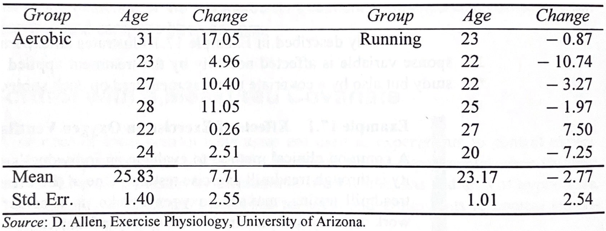

Which exercise program will lead to a greater average change in VO$_2$ max?

What role does age play?

# VO$_2$ max

```r
vo2max <- data.frame(chg = c(17.05,4.96,10.40,11.05,0.26,2.51,
                                -0.87,-10.74,-3.27,-1.97,7.50,-7.25),
                        grp = as.factor(c(rep("aerobic",6),rep("running",6))),
                        age = c(31,23,27,28,22,24,23,22,22,25,27,20))

vo2max
```

```
      chg     grp age
1   17.05 aerobic  31
2    4.96 aerobic  23
3   10.40 aerobic  27
4   11.05 aerobic  28
5    0.26 aerobic  22
6    2.51 aerobic  24
7   -0.87 running  23
8  -10.74 running  22
9   -3.27 running  22
10  -1.97 running  25
11   7.50 running  27
12  -7.25 running  20
```

# VO$_2$ max

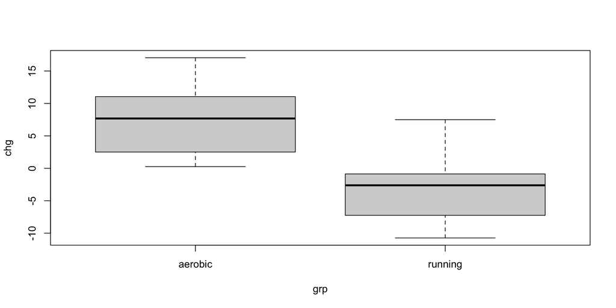

```r
boxplot(chg ~ grp, data = vo2max)
```

# VO$_2$ max

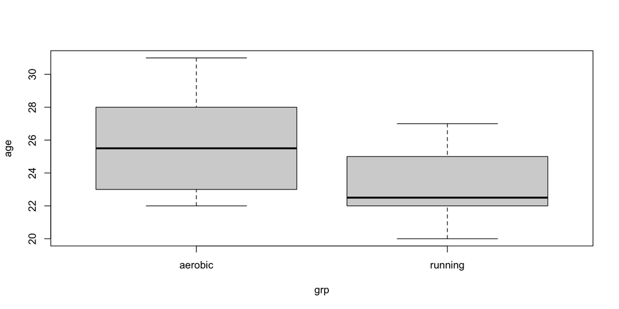

```r
boxplot(age ~ grp, data = vo2max)
```

# VO$_2$ max

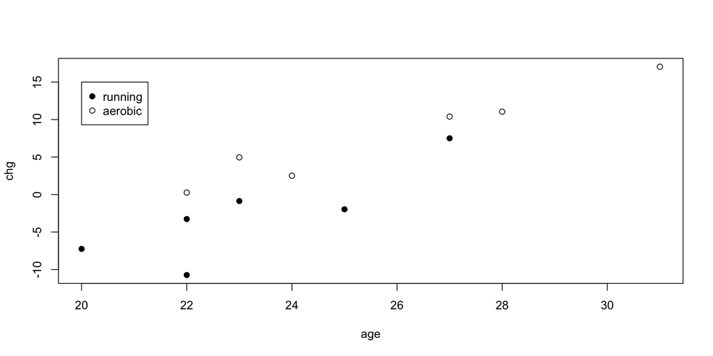

```r
plot(chg ~ age, pch = ifelse(grp == "running",19,1), data = vo2max)
legend(x = 20,y = 15,legend = c("running","aerobic"), pch = c(19,1))
```

# Analysis of covariance

- Useful when EUs are not homogeneous.
- Measurement capturing EU inhomogeneity is called a covariate.
- Can isolate treatment effects even when EUs differ across treatment groups.

# Single-slope analysis of covariance (ANCOVA) model

Assume
$$Y_{ij} = \mu + \tau_i + \beta x_{ij}+ \varepsilon_{ij}$$
for $i = 1,\dots,a$, $j = 1,\dots,n_i$, where

- $Y_{ij}$ is the response of EU $j$ in treatment group $i$.
- $\mu$ is a baseline or overall mean.
- the $\tau_i$ are treatment effects.
- the $x_{ij}$ are covariate values measured on the EUs.
- $\beta$ is a slope coefficient expressing the effect of the covariate.
- the $\varepsilon_{ij}$ are independent $\text{Normal}(0,\sigma_{\varepsilon}^2)$ error terms.
- $n_1 + \dots + n_a = N$. Unbalancedness not an issue.

Set $\mu_i = \mu + \tau_i$ for $i =1,\dots,a$.

# Goals in analysis of covariance

1. Estimate the parameters $\mu$, $\tau_1,\dots,\tau_a$, and $\beta$.
2. Visualize the data.
3. Fit full and reduced models and collect error sums of squares.
4. Test whether the covariate has any effect.
5. Test for a treatment effect.
6. Adjust treatment group means for the inhomogeneity of the EUs.
7. Compare the adjusted group means.

# Parameter constraints

# VO$_2$ max

```r
lm_out <- lm(chg ~ grp + age, data = vo2max)
summary(lm_out)
```

```
Call:
lm(formula = chg ~ grp + age, data = vo2max)

Residuals:
   Min     1Q Median     3Q    Max
 -5.77  -0.99   0.14   1.82   3.04

Coefficients:
            Estimate Std. Error t value Pr(>|t|)
(Intercept)  -41.014      7.714   -5.32  0.00048 ***
grprunning    -5.443      1.796   -3.03  0.01425 *
age            1.886      0.295    6.39  0.00013 ***
---
Signif. codes:  0 '***' 0.001 '**' 0.01 '*' 0.05 '.' 0.1 ' ' 1

Residual standard error: 2.8 on 9 degrees of freedom
Multiple R-squared:  0.902, Adjusted R-squared:  0.88
F-statistic: 41.4 on 2 and 9 DF,  p-value: 2.89e-05
```

# VO$_2$ max

```r
parms <- coef(lm_out)
parms
```

```
(Intercept)  grprunning         age
     -41.01       -5.44        1.89
```

# VO$_2$ max

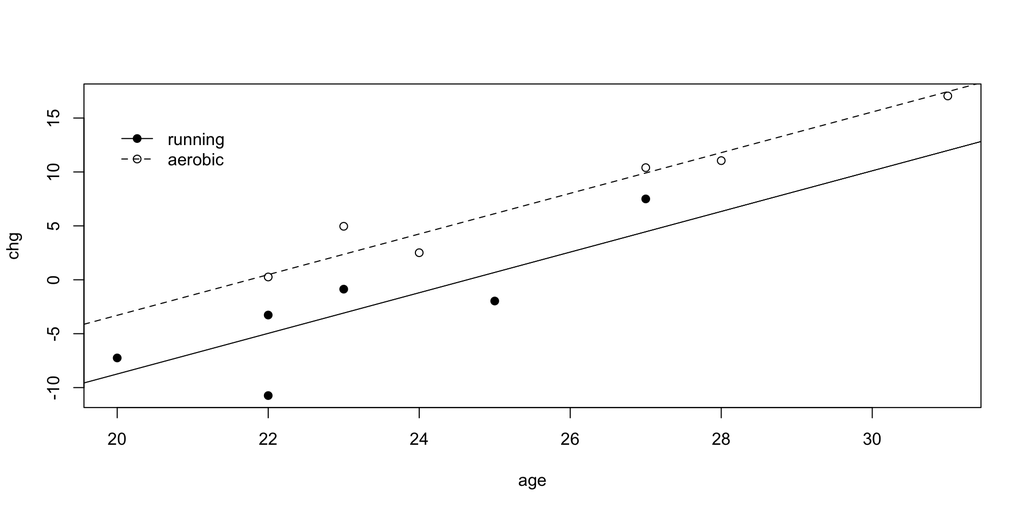

```r
plot(chg ~ age, pch = ifelse(grp == "running",19,1), data = vo2max)
abline(parms[1] + parms[2],parms[3])
abline(parms[1],parms[3],lty = 2)
legend(x = 20,y = 15,legend = c("running","aerobic"), pch = c(19,1), lty = c(1,2),bty = "n")
```